# Tutorial for mixed Poisson regression with brms

Bodo Winter & Paul Bürkner

29/10/2020

## Instructions

In this analysis, we’ll analyze gesture data with a multilevel Poisson model. This serves as an introduction to both generalized linear models and multilevel models.

## Prelims

First, let’s load the packages we’ll need. `tidyverse` for data processing, and `brms` for Bayesian regression models.

```r
library(tidyverse)
library(brms)
```

Next, load the `dyads.csv` dataset that contains gesture counts:

```r
dyads <- read_csv('dyads.csv')
```

It’s always a good idea to familiarize yourself with the data first. Check a few random rows of the tibble with the tidyverse function `sample_n()`. Here, we are drawing 4 random rows just to get a first impression. If you are in an interactive R session (rather than reading the knitted version of this markdown), consider repeating this command to get a few more random rows.

```r
sample_n(dyads, 4)
```

```
## # A tibble: 4 × 6
##   ID         context   dur language gender gestures
##   <chr>      <chr>   <dbl> <chr>    <chr>     <dbl>
## 1 Catalan_7  prof      131 Catalan  F            73
## 2 Korean_4   prof       75 Korean   F            30
## 3 Korean_5   friend    127 Korean   M            33
## 4 Catalan_12 friend    134 Catalan  M            58
```

Ok, so let me explain the content of the columns to you. First, we have the `ID` column, which are participant identifiers. Let’s check how many participants there are using the `count()` function:

```r
dyads %>%
  count(ID)
```

```
## # A tibble: 27 × 2
##    ID             n
##    <chr>      <int>
##  1 Catalan_1      2
##  2 Catalan_11     2
##  3 Catalan_12     2
##  4 Catalan_13     2
##  5 Catalan_14     2
##  6 Catalan_16     2
##  7 Catalan_2      2
##  8 Catalan_3      2
##  9 Catalan_4      2
## 10 Catalan_5      2
## # … with 17 more rows
```

This shows us that there are 2 data points per participant (one for each condition). By copy & pasting this pipe line and further piping it to the `nrow()` function we get the counts of all participants, because each row is one participant:

```r
dyads %>%
  count(ID) %>%
  nrow()
```

```
## [1] 27
```

Ok, so what about the other columns?

- `context`: the main condition variable, whether the participant spoke to a friend or a professor
- `dur`: the duration of each trial in seconds
- `language`: whether the participant was a speaker of Catalan or Korean
- `gender`: the self-identified gender of the participant (only two levels in this case, based on our participants’ responses)
- `gestures`: the main response variable, the count of gestures (unbounded count variable)

Let’s calculate the average number of gestures per condition (= context):

```r
dyads %>%
  group_by(context) %>%
  summarize(M = mean(gestures))
```

```
## # A tibble: 2 × 2
##   context     M
##   <chr>   <dbl>
## 1 friend   53.8
## 2 prof     45.1
```

Ok, so more gestures in the “friend” condition. This picture could be deceiving however, as the trials had unequal intervals, i.e., some were shorter, others were longer. It could be more informative to compute rates, and then compute means. We can do this by slotting in a `mutate()` function call into the pipeline above. Within this function, we compute rates by dividing the counts by the duration (= gestures per second).

```r
dyads %>%
  mutate(rate = gestures / dur) %>%
  group_by(context) %>%
  summarize(M = mean(rate))
```

```
## # A tibble: 2 × 2
##   context     M
##   <chr>   <dbl>
## 1 friend  0.398
## 2 prof    0.361
```

A slightly higher rate of gestures per second.

## Bayesian Poisson regression (no random effects)

Before we start doing anything with brms, let’s make sure that Stan uses all the cores on your system to run faster:

```r
options(mc.cores=parallel::detectCores())
```

Only for simple problems can the posterior distribution be calculated exactly. In most cases relevant to applied statistics, the posterior distribution has to be approximated instead.

Markov Chain Monte Carlo (MCMC) sampling is the most standard way to approximate the posterior distribution in modern Bayesian analysis. MCMC sampling is described in more detail in McElreath (2020) (“Statistical rethinking”), but for now, it suffices to say that it is a way of sampling from the (unknown) posterior distribution in a way that is proportionate to the posterior probability, i.e., more probable parameter values will correspond to more samples.

We’ll change the settings for MCMC sampling here. This was done because initial exploration showed that there were “divergent transitions”, which signals that there is some sort of degeneracy with the MCMC sampling process. Stan includes helpful error messages that suggest solutions to such issues, which in this case involved adjusting the following two parameters:

```r
mcmc_controls <- list(adapt_delta = 0.999,
                      max_treedepth = 13)
```

We’ll build up our model in pieces for pedagogical reasons, starting with a simple Poisson regression model. We are going to ignore random effects and prior specifications for now, both of which will be dealt with later. We’ll also deal with prior specifications later.

We fit the model. The core of the formula is “gestures ~ context”, the count of gestures as a function of context. The “1” stands for the intercept. You can omit it in R as all linear model functions, including `brm()` will fit an intercept by default, but it’s good to be explicit. As this is a term of your model that is actually estimated, the formula should reflect this.

```r
mdl <- brm(gestures ~ 1 + context,
           data = dyads,
           family = poisson,
           seed = 666)
```

Next, we summarize the model by simply typing in its name.

```r
mdl
```

```
##  Family: poisson
##   Links: mu = log
## Formula: gestures ~ 1 + context
##    Data: dyads (Number of observations: 54)
##   Draws: 4 chains, each with iter = 2000; warmup = 1000; thin = 1;
##          total post-warmup draws = 4000
##
## Population-Level Effects:
##             Estimate Est.Error l-95% CI u-95% CI Rhat Bulk_ESS Tail_ESS
## Intercept       3.99      0.03     3.93     4.04 1.00     3132     2710
## contextprof    -0.18      0.04    -0.26    -0.10 1.00     2952     2351
##
## Draws were sampled using sampling(NUTS). For each parameter, Bulk_ESS
## and Tail_ESS are effective sample size measures, and Rhat is the potential
## scale reduction factor on split chains (at convergence, Rhat = 1).
```

Let’s interpret what we got here. Your focus should be on the “Estimate” column, which is what we should strive to understand.

Use the `conditional_effects()` function to plot predicted values:

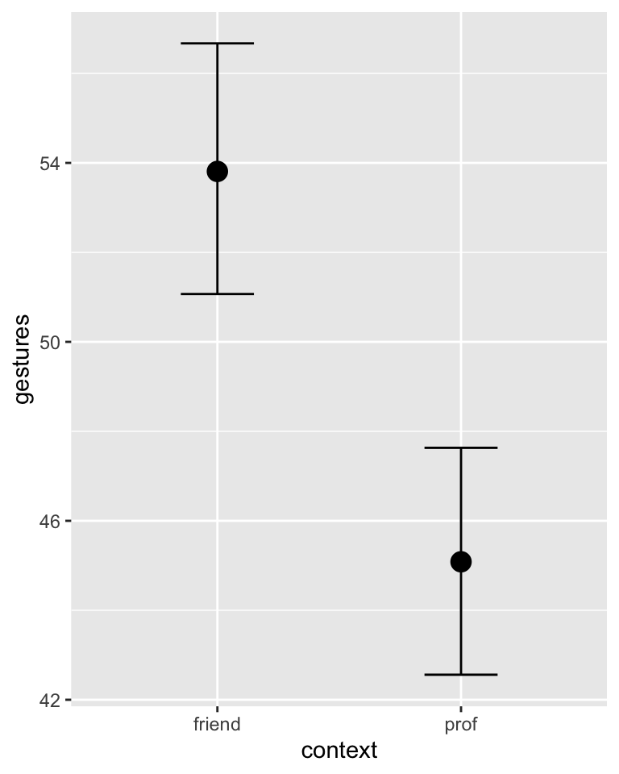

```r
conditional_effects(mdl)
```

This would be OK, but to reproduce the exact figure shown in the paper (Figure 3), we extracted the values from the `conditional_effects()` function to have more control over plotting parameters.

Or to create a more snazzy ggplot that we can modify ourselves, we can extract the values. The structure of this object is a list, and we use `[[1]]` here to extract the first element of the list.

```r
poisson_effects <- conditional_effects(mdl)[[1]]

# Check:

poisson_effects
```

```
##   context gestures cond__ effect1__ estimate__     se__  lower__  upper__
## 1  friend 49.44444      1    friend   53.80942 1.389007 51.06865 56.67220
## 2    prof 49.44444      1      prof   45.08409 1.294492 42.55968 47.63165
```

It would be good to rename the columns that involve "__":

```r
poisson_effects <- rename(poisson_effects,
                          estimate = `estimate__`,
                          lower = `lower__`,
                          upper = `upper__`)
```

Make a ggplot of this:

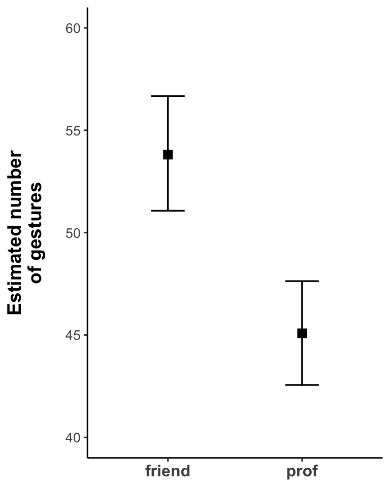

```r
## Define plot basics and geoms:

effects_p <- poisson_effects %>%
  ggplot(aes(x = context, y = estimate,
             ymin = lower, ymax = upper)) +
  geom_errorbar(width = 0.25, size = 0.6) +
  geom_point(size = 3, shape = 15)

# Define everything else, including plot cosmetics:

effects_p <- effects_p +
  theme_classic() +
  xlab(NULL) +
  ylab('Estimated number\nof gestures') +
  theme(axis.text.x = element_text(face = 'bold', size = 12),
        axis.title.y = element_text(margin = margin(r = 15, l= 0,
                                                    t = 0, b = 0),
                                    face = 'bold', size = 14),
        axis.text.y = element_text(size = 10)) +
  scale_y_continuous(limits = c(40, 60))

# Plot:

effects_p
```

```r
ggsave(plot = effects_p, filename = 'conditional_effects.pdf',
       width = 4, height = 5)
```

To calculate values by hand, we use ``hypothesis()`. The following evaluates the difference between the professor (dummy code = 1) and the friend (dummy code = 0) condition. The exp() is there so that the function returns raw gesture counts (rather than estimated log lambdas).

```r
h <- 'exp(Intercept + contextprof * 1) = exp(Intercept + contextprof * 0)'
hypothesis(mdl, h)
```

```
## Hypothesis Tests for class b:
##                 Hypothesis Estimate Est.Error CI.Lower CI.Upper Evid.Ratio
## 1 (exp(Intercept+co... = 0    -8.77       1.9   -12.61    -5.06         NA
##   Post.Prob Star
## 1        NA    *
## ---
## 'CI': 90%-CI for one-sided and 95%-CI for two-sided hypotheses.
## '*': For one-sided hypotheses, the posterior probability exceeds 95%;
## for two-sided hypotheses, the value tested against lies outside the 95%-CI.
## Posterior probabilities of point hypotheses assume equal prior probabilities.
```

```r
hypothesis(mdl, 'exp(Intercept + contextprof * 1) = 0')
```

```
## Hypothesis Tests for class b:
##                 Hypothesis Estimate Est.Error CI.Lower CI.Upper Evid.Ratio
## 1 (exp(Intercept+co... = 0    45.07      1.29    42.56    47.63         NA
##   Post.Prob Star
## 1        NA    *
## ---
## 'CI': 90%-CI for one-sided and 95%-CI for two-sided hypotheses.
## '*': For one-sided hypotheses, the posterior probability exceeds 95%;
## for two-sided hypotheses, the value tested against lies outside the 95%-CI.
## Posterior probabilities of point hypotheses assume equal prior probabilities.
```

```r
hypothesis(mdl, 'exp(Intercept + contextprof * 0) = 0')
```

```
## Hypothesis Tests for class b:
##                 Hypothesis Estimate Est.Error CI.Lower CI.Upper Evid.Ratio
## 1 (exp(Intercept+co... = 0    53.85      1.41    51.07    56.67         NA
##   Post.Prob Star
## 1        NA    *
## ---
## 'CI': 90%-CI for one-sided and 95%-CI for two-sided hypotheses.
## '*': For one-sided hypotheses, the posterior probability exceeds 95%;
## for two-sided hypotheses, the value tested against lies outside the 95%-CI.
## Posterior probabilities of point hypotheses assume equal prior probabilities.
```

## Incorporating random effects

As the data includes repeated measures per individual, the above model violates the independence assumption. A simple Poisson regression model does not use the heterogeneity across speakers for inference, thus potentially grossly misrepresenting the data. To deal with the fact that there are repeated samples per speakers and per items, we need to incorporate random effects. First, let’s go with a random intercept only model:

```r
# Fit:

mixed_mdl <- brm(gestures ~ 1 + context + (1|ID),
                 control = mcmc_controls,
                 seed = 666,
                 data = dyads, family = poisson,
                 warmup = 4000, iter = 8000)
# Show:

mixed_mdl
```

```
##  Family: poisson
##   Links: mu = log
## Formula: gestures ~ 1 + context + (1 | ID)
##    Data: dyads (Number of observations: 54)
##   Draws: 4 chains, each with iter = 8000; warmup = 4000; thin = 1;
##          total post-warmup draws = 16000
##
## Group-Level Effects:
## ~ID (Number of levels: 27)
##               Estimate Est.Error l-95% CI u-95% CI Rhat Bulk_ESS Tail_ESS
## sd(Intercept)     0.50      0.08     0.37     0.68 1.00     1797     2711
##
## Population-Level Effects:
##             Estimate Est.Error l-95% CI u-95% CI Rhat Bulk_ESS Tail_ESS
## Intercept       3.88      0.10     3.68     4.08 1.00     1398     2174
## contextprof    -0.18      0.04    -0.25    -0.10 1.00    10513    10461
##
## Draws were sampled using sampling(NUTS). For each parameter, Bulk_ESS
## and Tail_ESS are effective sample size measures, and Rhat is the potential
## scale reduction factor on split chains (at convergence, Rhat = 1).
```

This model allows for different individuals to have different overall gesture counts. However, because the model is lacking random slopes for the effect of context, it assumes that the effect of context is constant across all individuals. This is an unreasonable assumption to make in this case, as surely some people’s gesture rates could me more affected by the friend vs. professor manipulation than others. Therefore, we add random slopes:

```r
mixed_mdl <- brm(gestures ~ 1 + context + (1 + context|ID),
                 data = dyads, family = poisson,
                 control = mcmc_controls,
                 seed = 666,
                 warmup = 4000, iter = 8000)
# Show:

mixed_mdl
```

```
##  Family: poisson
##   Links: mu = log
## Formula: gestures ~ 1 + context + (1 + context | ID)
##    Data: dyads (Number of observations: 54)
##   Draws: 4 chains, each with iter = 8000; warmup = 4000; thin = 1;
##          total post-warmup draws = 16000
##
## Group-Level Effects:
## ~ID (Number of levels: 27)
##                            Estimate Est.Error l-95% CI u-95% CI Rhat Bulk_ESS
## sd(Intercept)                  0.46      0.08     0.34     0.64 1.00     4912
## sd(contextprof)                0.29      0.07     0.16     0.45 1.00     6836
## cor(Intercept,contextprof)     0.26      0.25    -0.25     0.71 1.00     7862
##                            Tail_ESS
## sd(Intercept)                  8101
## sd(contextprof)                8976
## cor(Intercept,contextprof)     9842
##
## Population-Level Effects:
##             Estimate Est.Error l-95% CI u-95% CI Rhat Bulk_ESS Tail_ESS
## Intercept       3.90      0.09     3.71     4.08 1.00     3002     5734
## contextprof    -0.23      0.07    -0.37    -0.09 1.00     8904     9990
##
## Draws were sampled using sampling(NUTS). For each parameter, Bulk_ESS
## and Tail_ESS are effective sample size measures, and Rhat is the potential
## scale reduction factor on split chains (at convergence, Rhat = 1).
```

## Incorporating an exposure variable

The model above does not account for the fact that counts were observed for unequal time intervals. We add the exposure variable as a logged term:

```r
exposure_mdl <- brm(gestures ~ 1 + context + offset(log(dur)) +
                      (1 + context|ID),
                    data = dyads, family = poisson,
                    control = mcmc_controls,
                    seed = 666,
                    warmup = 4000, iter = 8000,
                    save_all_pars = TRUE)
# Show:

exposure_mdl
```

```
##  Family: poisson
##   Links: mu = log
## Formula: gestures ~ 1 + context + offset(log(dur)) + (1 + context | ID)
##    Data: dyads (Number of observations: 54)
##   Draws: 4 chains, each with iter = 8000; warmup = 4000; thin = 1;
##          total post-warmup draws = 16000
##
## Group-Level Effects:
## ~ID (Number of levels: 27)
##                            Estimate Est.Error l-95% CI u-95% CI Rhat Bulk_ESS
## sd(Intercept)                  0.35      0.06     0.24     0.49 1.00     5024
## sd(contextprof)                0.17      0.07     0.03     0.32 1.00     3394
## cor(Intercept,contextprof)     0.36      0.35    -0.39     0.94 1.00     6861
##                            Tail_ESS
## sd(Intercept)                  8854
## sd(contextprof)                3480
## cor(Intercept,contextprof)     5646
##
## Population-Level Effects:
##             Estimate Est.Error l-95% CI u-95% CI Rhat Bulk_ESS Tail_ESS
## Intercept      -0.97      0.07    -1.12    -0.83 1.00     2800     4935
## contextprof    -0.12      0.06    -0.24    -0.01 1.00     8351     9066
##
## Draws were sampled using sampling(NUTS). For each parameter, Bulk_ESS
## and Tail_ESS are effective sample size measures, and Rhat is the potential
## scale reduction factor on split chains (at convergence, Rhat = 1).
```

Calculate the predicted values separately for each condition:

```r
friend_h <- 'exp(Intercept + contextprof * 0) = 0'
hypothesis(exposure_mdl, friend_h)
```

```
## Hypothesis Tests for class b:
##                 Hypothesis Estimate Est.Error CI.Lower CI.Upper Evid.Ratio
## 1 (exp(Intercept+co... = 0     0.38      0.03     0.33     0.44         NA
##   Post.Prob Star
## 1        NA    *
## ---
## 'CI': 90%-CI for one-sided and 95%-CI for two-sided hypotheses.
## '*': For one-sided hypotheses, the posterior probability exceeds 95%;
## for two-sided hypotheses, the value tested against lies outside the 95%-CI.
## Posterior probabilities of point hypotheses assume equal prior probabilities.
```

```r
prof_h <- 'exp(Intercept + contextprof * 1) = 0'
hypothesis(exposure_mdl, prof_h)
```

```
## Hypothesis Tests for class b:
##                 Hypothesis Estimate Est.Error CI.Lower CI.Upper Evid.Ratio
## 1 (exp(Intercept+co... = 0     0.34      0.03     0.28      0.4         NA
##   Post.Prob Star
## 1        NA    *
## ---
## 'CI': 90%-CI for one-sided and 95%-CI for two-sided hypotheses.
## '*': For one-sided hypotheses, the posterior probability exceeds 95%;
## for two-sided hypotheses, the value tested against lies outside the 95%-CI.
## Posterior probabilities of point hypotheses assume equal prior probabilities.
```

Notice that these values are now much smaller than what was discussed above because due to the addition of the exposure variable, results are reported as rates per second rather than raw counts.

## Switching to a negative binomial model

As mentioned in the body of the text, the variance is exactly equal to the mean for the Poisson distribution. This mean = variance assumption can easily be demonstrated by drawing 10,000 random numbers from the Poisson distribution at two specified lambdas, lambda = and lambda = 4, corresponding to Figure 1 in the paper.

```r
var(rpois(10000, lambda = 1))
```

```
## [1] 1.006191
```

```r
var(rpois(10000, lambda = 4))
```

```
## [1] 3.995375
```

Notice that the variance of the first set of random draws (y1) approximates 1, and the variance of the second set of random draws (y4) approximates 4, which are the corresponding lambda values. In the context of the Poisson distribution, the variance is also called “dispersion”.

It is possible that there is overdispersion in the data (i.e., variance > mean than what is expected under Poisson). To explore this, let’s switch to a negative binomial model:

```r
negbinom_mdl <- brm(gestures | rate(dur) ~ 1 + context  +
                      (1 + context|ID),
                    data = dyads, family = negbinomial,
                    control = mcmc_controls,
                seed = 666,
                warmup = 4000, iter = 8000,
                save_all_pars = TRUE)
# Show:

negbinom_mdl
```

```
##  Family: negbinomial
##   Links: mu = log; shape = identity
## Formula: gestures | rate(dur) ~ 1 + context + (1 + context | ID)
##    Data: dyads (Number of observations: 54)
##   Draws: 4 chains, each with iter = 8000; warmup = 4000; thin = 1;
##          total post-warmup draws = 16000
##
## Group-Level Effects:
## ~ID (Number of levels: 27)
##                            Estimate Est.Error l-95% CI u-95% CI Rhat Bulk_ESS
## sd(Intercept)                  0.35      0.07     0.24     0.49 1.00     5425
## sd(contextprof)                0.15      0.08     0.01     0.31 1.00     2778
## cor(Intercept,contextprof)     0.38      0.39    -0.50     0.96 1.00     7844
##                            Tail_ESS
## sd(Intercept)                  8799
## sd(contextprof)                4162
## cor(Intercept,contextprof)     6628
##
## Population-Level Effects:
##             Estimate Est.Error l-95% CI u-95% CI Rhat Bulk_ESS Tail_ESS
## Intercept      -0.97      0.08    -1.12    -0.82 1.00     2844     5178
## contextprof    -0.12      0.06    -0.23    -0.01 1.00     9894    11193
##
## Family Specific Parameters:
##       Estimate Est.Error l-95% CI u-95% CI Rhat Bulk_ESS Tail_ESS
## shape    19.45     40.08     0.30   138.68 1.00     5622     7314
##
## Draws were sampled using sampling(NUTS). For each parameter, Bulk_ESS
## and Tail_ESS are effective sample size measures, and Rhat is the potential
## scale reduction factor on split chains (at convergence, Rhat = 1).
```

We can assess whether there is enough overdispersion in the data to warrant a negative binomial model.

```r
# LOO-CV per model:

pois_loo <- loo(exposure_mdl, moment_match = TRUE)
negbinom_loo <- loo(negbinom_mdl, moment_match = TRUE)
# Compare:

loos <- loo_compare(pois_loo, negbinom_loo)

# Show:

loos
```

```
##              elpd_diff se_diff
## negbinom_mdl  0.0       0.0
## exposure_mdl -0.1       0.7
```

In this particular case, there is no stark difference between the two models. This may lead us to choose the simpler Poisson model (which contains one parameter less). However, as a default, negative binomial models are more likely going to be the conservative choice as overdispersion is very common in linguistic data (see discussion in main body of text).

## Specifying priors

Visualize different prior configurations for slope term (weakly informative priors with normal distributions centered at zero and different standard deviations). This reproduces Figure 5 in the paper.

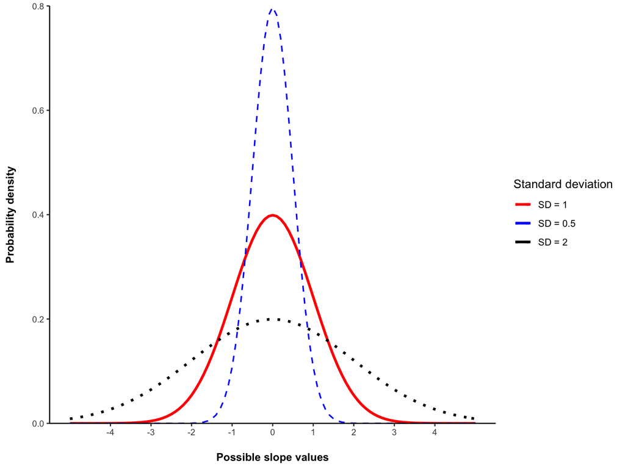

```r
prior_p <- ggplot(data = tibble(x = c(-5, 5)), aes(x = x)) +
  stat_function(fun = dnorm, n = 101,
                args = list(mean = 0, sd = 1),
                aes(color = 'red'), size = 1.15) +
  stat_function(fun = dnorm, n = 101,
                args = list(mean = 0, sd = 0.5), linetype = 2,
                aes(color = 'blue'), size = 0.65) +
  stat_function(fun = dnorm, n = 101,
                args = list(mean = 0, sd = 2), linetype = 3,
                aes(color = 'black'), size = 1.15) +
  scale_color_manual(values = c('red', 'blue', 'black'),
                     name = 'Standard deviation',
                     breaks = c('red', 'blue', 'black'),
                     labels = c('SD = 1', 'SD = 0.5', 'SD = 2')) +
  scale_x_continuous(breaks = -4:4) +
  scale_y_continuous(name = 'Probability density', expand = c(0, 0)) +
  theme_classic() +
  theme(panel.grid.major = element_blank(),
        panel.grid.minor = element_blank(),
        axis.text.x = element_text(size = 8),
        axis.text.y = element_text(size = 8),
        axis.title.y = element_text(face = 'bold', size = 10,
                                    margin = margin(r = 15, l = 0,
                                                    t = 0, b = 0)),
        axis.title.x = element_text(face = 'bold', size = 10,
                                    margin = margin(r = 0, l = 0,
                                                    t = 15, b = 0))) +
  coord_cartesian(ylim = c(0, 0.8)) +
  xlab('Possible slope values')

# Show and save:

prior_p
```

```r
ggsave(plot = prior_p, filename = 'slope_prior_options.pdf',
       width = 6, height = 3)
```

We focus on specifying a weakly informative prior on the slope. Importantly, readers should also consider priors for the other parameters of the model, which is discussed in more detail with linguistic examples in Vasishth et al. (2018) and Nalborczyk et al. (2019).

```r
weak_priors <- prior(normal(0, 0.5), class = b)
```

We add the prior to the negative binomial model:

```r
negbinom_mdl <- brm(gestures | rate(dur) ~ 1 + context +
                      (1 + context|ID),
                    data = dyads, family = negbinomial,
                    control = mcmc_controls,
                    prior = weak_priors,
                seed = 666,
                warmup = 4000, iter = 8000)
# Show:

negbinom_mdl
```

```
##  Family: negbinomial
##   Links: mu = log; shape = identity
## Formula: gestures | rate(dur) ~ 1 + context + (1 + context | ID)
##    Data: dyads (Number of observations: 54)
##   Draws: 4 chains, each with iter = 8000; warmup = 4000; thin = 1;
##          total post-warmup draws = 16000
##
## Group-Level Effects:
## ~ID (Number of levels: 27)
##                            Estimate Est.Error l-95% CI u-95% CI Rhat Bulk_ESS
## sd(Intercept)                  0.35      0.07     0.24     0.50 1.00     5210
## sd(contextprof)                0.15      0.08     0.01     0.31 1.00     3167
## cor(Intercept,contextprof)     0.37      0.39    -0.51     0.96 1.00     9600
##                            Tail_ESS
## sd(Intercept)                  8835
## sd(contextprof)                5164
## cor(Intercept,contextprof)     8033
##
## Population-Level Effects:
##             Estimate Est.Error l-95% CI u-95% CI Rhat Bulk_ESS Tail_ESS
## Intercept      -0.97      0.08    -1.12    -0.82 1.00     3258     6290
## contextprof    -0.11      0.06    -0.23    -0.00 1.00    12293    11109
##
## Family Specific Parameters:
##       Estimate Est.Error l-95% CI u-95% CI Rhat Bulk_ESS Tail_ESS
## shape    19.46     40.10     0.30   129.83 1.00     5451     6610
##
## Draws were sampled using sampling(NUTS). For each parameter, Bulk_ESS
## and Tail_ESS are effective sample size measures, and Rhat is the potential
## scale reduction factor on split chains (at convergence, Rhat = 1).
```

## Posterior predictive checks

Assess model adequacy with posterior predicticve checks. First, we use the `pp_check()` function with its default:

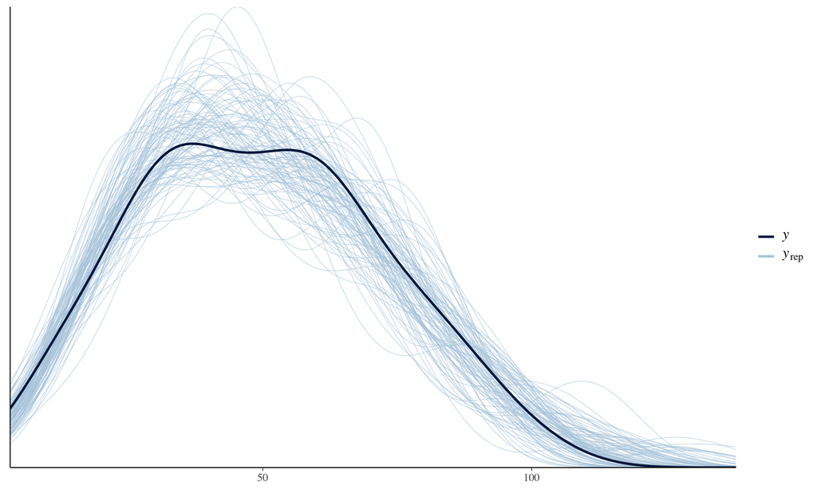

```r
pp_smooth <- pp_check(negbinom_mdl, ndraws =  100)

# Show and save:

pp_smooth
```

```r
ggsave(plot = pp_smooth, filename = 'pp_checks.pdf',
       width = 8, height = 6)
```

This is not optimal however because `pp_check()` by default smooths, which is not ideal for discrete count data. Instead, we recommend using the ECDF (empirical cumulative distribution function):

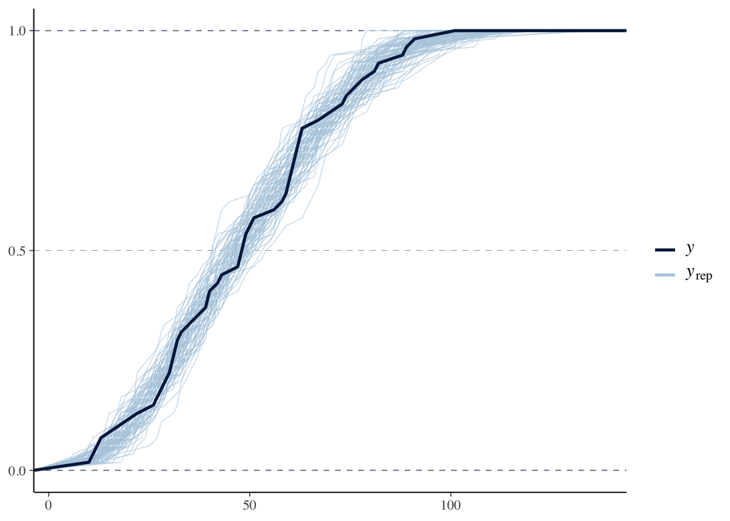

```r
pp_ecdf <- pp_check(negbinom_mdl, ndraws =  100,
                    type = 'ecdf_overlay')

# Show and save:

pp_ecdf
```

```r
ggsave(plot = pp_ecdf, filename = 'pp_checks_ecdf.pdf',
       width = 7, height = 5)
```

The black line falls quite firmly into the blue lines, suggesting that this model could have generated the data. There are no obvious discrepancies suggested by this plot.

## Inference and substantive evaluation

We can calculate the posterior probability of the effect being below zero:

```r
hypothesis(negbinom_mdl, 'contextprof < 0')
```

```
## Hypothesis Tests for class b:
##          Hypothesis Estimate Est.Error CI.Lower CI.Upper Evid.Ratio Post.Prob
## 1 (contextprof) < 0    -0.11      0.06    -0.21    -0.02      47.34      0.98
##   Star
## 1    *
## ---
## 'CI': 90%-CI for one-sided and 95%-CI for two-sided hypotheses.
## '*': For one-sided hypotheses, the posterior probability exceeds 95%;
## for two-sided hypotheses, the value tested against lies outside the 95%-CI.
## Posterior probabilities of point hypotheses assume equal prior probabilities.
```

Extract posterior samples for plotting:

```r
posts <- posterior_samples(negbinom_mdl)
# Show first 3 rows of the first 9 columns:

posts %>%
  slice_head(n = 3) %>%
  select(1:2)
```

```
##   b_Intercept b_contextprof
## 1  -0.8757060   -0.23311466
## 2  -0.9121099   -0.14479366
## 3  -1.0829616   -0.09226263
```

Visualize the posterior distribution based on this data.

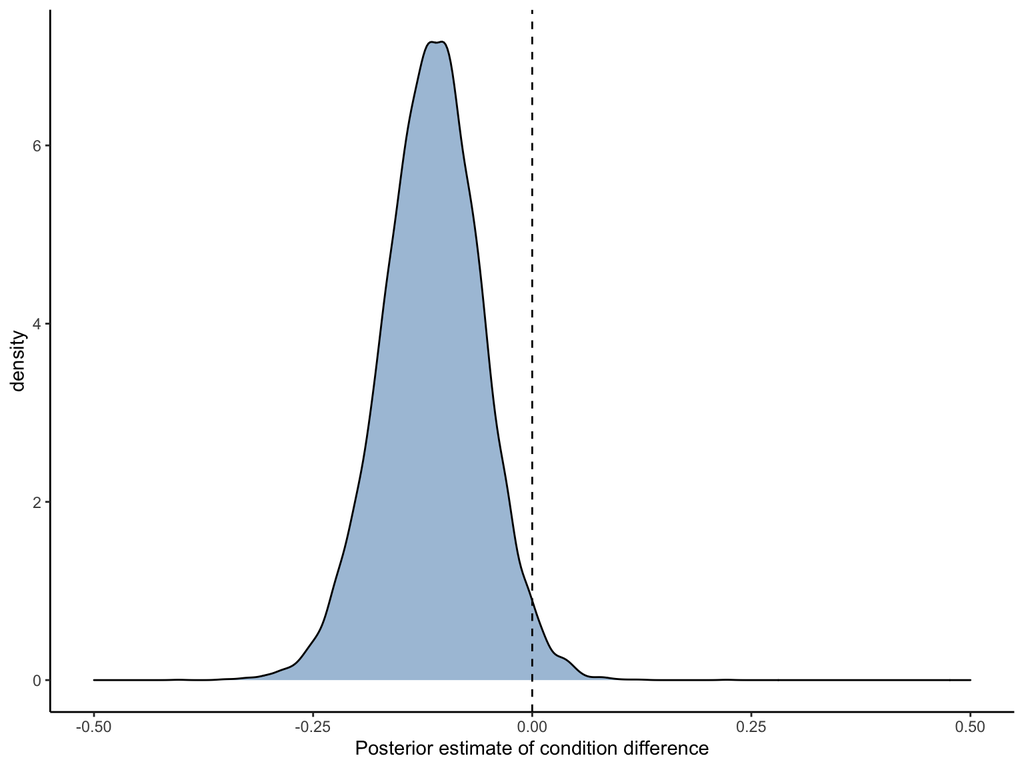

```r
post_p <- posts %>%
  ggplot(aes(x = b_contextprof)) +
  geom_density(fill = 'steelblue', alpha = 0.5) +
  geom_vline(aes(xintercept = 0), linetype = 2) +
  theme_classic() +
  theme(panel.grid.major = element_blank(),
        panel.grid.minor = element_blank()) +
  xlab('Posterior estimate of condition difference') +
  xlim(c(-0.5, 0.5))

# Show and save:

post_p
```

```r
ggsave(plot = post_p, filename = 'slope_posterior.pdf',
       width = 6, height = 4)
```

This completes this analysis.